# Risk Factor Analysis

## Outcome Variable

**Outcome Variable:** pers_wast

## Predictor Variables

**Intervention Variable:** mbmi

**Adjustment Set:**

unadjusted

## Stratifying Variables

The analysis was stratified on these variable(s):

- agecat
- studyid
- country

## Data Summary

| agecat | studyid | country | mbmi | pers_wast | n_cell | n |
| --- | --- | --- | --- | --- | --- | --- |
| 0-24 months | ki0047075b-MAL-ED | BANGLADESH | Normal weight | 0 | 150 | 248 |
| 0-24 months | ki0047075b-MAL-ED | BANGLADESH | Normal weight | 1 | 8 | 248 |
| 0-24 months | ki0047075b-MAL-ED | BANGLADESH | Underweight | 0 | 27 | 248 |
| 0-24 months | ki0047075b-MAL-ED | BANGLADESH | Underweight | 1 | 5 | 248 |
| 0-24 months | ki0047075b-MAL-ED | BANGLADESH | Overweight or Obese | 0 | 58 | 248 |
| 0-24 months | ki0047075b-MAL-ED | BANGLADESH | Overweight or Obese | 1 | 0 | 248 |
| 0-24 months | ki0047075b-MAL-ED | BRAZIL | Normal weight | 0 | 84 | 216 |
| 0-24 months | ki0047075b-MAL-ED | BRAZIL | Normal weight | 1 | 1 | 216 |
| 0-24 months | ki0047075b-MAL-ED | BRAZIL | Underweight | 0 | 10 | 216 |
| 0-24 months | ki0047075b-MAL-ED | BRAZIL | Underweight | 1 | 0 | 216 |
| 0-24 months | ki0047075b-MAL-ED | BRAZIL | Overweight or Obese | 0 | 120 | 216 |
| 0-24 months | ki0047075b-MAL-ED | BRAZIL | Overweight or Obese | 1 | 1 | 216 |
| 0-24 months | ki0047075b-MAL-ED | INDIA | Normal weight | 0 | 130 | 240 |
| 0-24 months | ki0047075b-MAL-ED | INDIA | Normal weight | 1 | 11 | 240 |
| 0-24 months | ki0047075b-MAL-ED | INDIA | Underweight | 0 | 42 | 240 |
| 0-24 months | ki0047075b-MAL-ED | INDIA | Underweight | 1 | 7 | 240 |
| 0-24 months | ki0047075b-MAL-ED | INDIA | Overweight or Obese | 0 | 47 | 240 |
| 0-24 months | ki0047075b-MAL-ED | INDIA | Overweight or Obese | 1 | 3 | 240 |
| 0-24 months | ki0047075b-MAL-ED | NEPAL | Normal weight | 0 | 130 | 238 |
| 0-24 months | ki0047075b-MAL-ED | NEPAL | Normal weight | 1 | 4 | 238 |
| 0-24 months | ki0047075b-MAL-ED | NEPAL | Underweight | 0 | 0 | 238 |
| 0-24 months | ki0047075b-MAL-ED | NEPAL | Underweight | 1 | 0 | 238 |
| 0-24 months | ki0047075b-MAL-ED | NEPAL | Overweight or Obese | 0 | 104 | 238 |
| 0-24 months | ki0047075b-MAL-ED | NEPAL | Overweight or Obese | 1 | 0 | 238 |
| 0-24 months | ki0047075b-MAL-ED | PERU | Normal weight | 0 | 153 | 283 |
| 0-24 months | ki0047075b-MAL-ED | PERU | Normal weight | 1 | 1 | 283 |
| 0-24 months | ki0047075b-MAL-ED | PERU | Underweight | 0 | 5 | 283 |
| 0-24 months | ki0047075b-MAL-ED | PERU | Underweight | 1 | 0 | 283 |
| 0-24 months | ki0047075b-MAL-ED | PERU | Overweight or Obese | 0 | 124 | 283 |
| 0-24 months | ki0047075b-MAL-ED | PERU | Overweight or Obese | 1 | 0 | 283 |

[output cut: 216 more lines]

The following strata were considered:

- agecat: 0-24 months, studyid: ki0047075b-MAL-ED, country: BANGLADESH
- agecat: 0-24 months, studyid: ki0047075b-MAL-ED, country: BRAZIL
- agecat: 0-24 months, studyid: ki0047075b-MAL-ED, country: INDIA
- agecat: 0-24 months, studyid: ki0047075b-MAL-ED, country: NEPAL
- agecat: 0-24 months, studyid: ki0047075b-MAL-ED, country: PERU
- agecat: 0-24 months, studyid: ki0047075b-MAL-ED, country: SOUTH AFRICA
- agecat: 0-24 months, studyid: ki0047075b-MAL-ED, country: TANZANIA, UNITED REPUBLIC OF
- agecat: 0-24 months, studyid: ki1000304b-SAS-CompFeed, country: INDIA
- agecat: 0-24 months, studyid: ki1017093-NIH-Birth, country: BANGLADESH
- agecat: 0-24 months, studyid: ki1017093b-PROVIDE, country: BANGLADESH
- agecat: 0-24 months, studyid: ki1017093c-NIH-Crypto, country: BANGLADESH
- agecat: 0-24 months, studyid: ki1066203-TanzaniaChild2, country: TANZANIA, UNITED REPUBLIC OF
- agecat: 0-24 months, studyid: ki1112895-iLiNS-Zinc, country: BURKINA FASO
- agecat: 0-24 months, studyid: ki1119695-PROBIT, country: BELARUS
- agecat: 0-24 months, studyid: ki1126311-ZVITAMBO, country: ZIMBABWE
- agecat: 0-24 months, studyid: ki1148112-LCNI-5, country: MALAWI
- agecat: 0-6 months, studyid: ki0047075b-MAL-ED, country: BANGLADESH
- agecat: 0-6 months, studyid: ki0047075b-MAL-ED, country: BRAZIL
- agecat: 0-6 months, studyid: ki0047075b-MAL-ED, country: INDIA
- agecat: 0-6 months, studyid: ki0047075b-MAL-ED, country: NEPAL
- agecat: 0-6 months, studyid: ki0047075b-MAL-ED, country: PERU
- agecat: 0-6 months, studyid: ki0047075b-MAL-ED, country: SOUTH AFRICA
- agecat: 0-6 months, studyid: ki0047075b-MAL-ED, country: TANZANIA, UNITED REPUBLIC OF
- agecat: 0-6 months, studyid: ki1017093b-PROVIDE, country: BANGLADESH
- agecat: 0-6 months, studyid: ki1066203-TanzaniaChild2, country: TANZANIA, UNITED REPUBLIC OF
- agecat: 6-24 months, studyid: ki0047075b-MAL-ED, country: BANGLADESH
- agecat: 6-24 months, studyid: ki0047075b-MAL-ED, country: BRAZIL
- agecat: 6-24 months, studyid: ki0047075b-MAL-ED, country: INDIA
- agecat: 6-24 months, studyid: ki0047075b-MAL-ED, country: NEPAL
- agecat: 6-24 months, studyid: ki0047075b-MAL-ED, country: PERU
- agecat: 6-24 months, studyid: ki0047075b-MAL-ED, country: SOUTH AFRICA
- agecat: 6-24 months, studyid: ki0047075b-MAL-ED, country: TANZANIA, UNITED REPUBLIC OF
- agecat: 6-24 months, studyid: ki1000304b-SAS-CompFeed, country: INDIA
- agecat: 6-24 months, studyid: ki1017093-NIH-Birth, country: BANGLADESH
- agecat: 6-24 months, studyid: ki1017093b-PROVIDE, country: BANGLADESH
- agecat: 6-24 months, studyid: ki1017093c-NIH-Crypto, country: BANGLADESH
- agecat: 6-24 months, studyid: ki1066203-TanzaniaChild2, country: TANZANIA, UNITED REPUBLIC OF
- agecat: 6-24 months, studyid: ki1112895-iLiNS-Zinc, country: BURKINA FASO
- agecat: 6-24 months, studyid: ki1119695-PROBIT, country: BELARUS
- agecat: 6-24 months, studyid: ki1126311-ZVITAMBO, country: ZIMBABWE
- agecat: 6-24 months, studyid: ki1148112-LCNI-5, country: MALAWI

### Dropped Strata

Some strata were dropped due to rare outcomes:

- agecat: 0-24 months, studyid: ki0047075b-MAL-ED, country: BANGLADESH
- agecat: 0-24 months, studyid: ki0047075b-MAL-ED, country: BRAZIL
- agecat: 0-24 months, studyid: ki0047075b-MAL-ED, country: INDIA
- agecat: 0-24 months, studyid: ki0047075b-MAL-ED, country: NEPAL
- agecat: 0-24 months, studyid: ki0047075b-MAL-ED, country: PERU
- agecat: 0-24 months, studyid: ki0047075b-MAL-ED, country: SOUTH AFRICA
- agecat: 0-24 months, studyid: ki0047075b-MAL-ED, country: TANZANIA, UNITED REPUBLIC OF
- agecat: 0-24 months, studyid: ki1000304b-SAS-CompFeed, country: INDIA
- agecat: 0-24 months, studyid: ki1017093-NIH-Birth, country: BANGLADESH
- agecat: 0-24 months, studyid: ki1017093b-PROVIDE, country: BANGLADESH
- agecat: 0-24 months, studyid: ki1017093c-NIH-Crypto, country: BANGLADESH
- agecat: 0-24 months, studyid: ki1066203-TanzaniaChild2, country: TANZANIA, UNITED REPUBLIC OF
- agecat: 0-24 months, studyid: ki1119695-PROBIT, country: BELARUS
- agecat: 0-24 months, studyid: ki1148112-LCNI-5, country: MALAWI
- agecat: 0-6 months, studyid: ki0047075b-MAL-ED, country: BANGLADESH
- agecat: 0-6 months, studyid: ki0047075b-MAL-ED, country: BRAZIL
- agecat: 0-6 months, studyid: ki0047075b-MAL-ED, country: INDIA
- agecat: 0-6 months, studyid: ki0047075b-MAL-ED, country: NEPAL
- agecat: 0-6 months, studyid: ki0047075b-MAL-ED, country: PERU
- agecat: 0-6 months, studyid: ki0047075b-MAL-ED, country: SOUTH AFRICA
- agecat: 0-6 months, studyid: ki0047075b-MAL-ED, country: TANZANIA, UNITED REPUBLIC OF
- agecat: 0-6 months, studyid: ki1017093b-PROVIDE, country: BANGLADESH
- agecat: 0-6 months, studyid: ki1066203-TanzaniaChild2, country: TANZANIA, UNITED REPUBLIC OF
- agecat: 6-24 months, studyid: ki0047075b-MAL-ED, country: BANGLADESH
- agecat: 6-24 months, studyid: ki0047075b-MAL-ED, country: BRAZIL
- agecat: 6-24 months, studyid: ki0047075b-MAL-ED, country: INDIA
- agecat: 6-24 months, studyid: ki0047075b-MAL-ED, country: NEPAL
- agecat: 6-24 months, studyid: ki0047075b-MAL-ED, country: PERU
- agecat: 6-24 months, studyid: ki0047075b-MAL-ED, country: SOUTH AFRICA
- agecat: 6-24 months, studyid: ki0047075b-MAL-ED, country: TANZANIA, UNITED REPUBLIC OF
- agecat: 6-24 months, studyid: ki1017093-NIH-Birth, country: BANGLADESH
- agecat: 6-24 months, studyid: ki1066203-TanzaniaChild2, country: TANZANIA, UNITED REPUBLIC OF
- agecat: 6-24 months, studyid: ki1119695-PROBIT, country: BELARUS
- agecat: 6-24 months, studyid: ki1148112-LCNI-5, country: MALAWI

## Methods Detail

We’re interested in the causal parameters $E[Y_a]$ for all values of $a \in \mathcal{A}$. These parameters represent the mean outcome if, possibly contrary to fact, we intervened to set all units to have $A=a$. Under the randomization and positivity assumptions, these are identified by the statistical parameters $\psi_a=E_W[E_{Y|A,W}(Y|A=a,W)]$. In addition, we’re interested in the mean of $Y$, $E[Y]$ under no intervention (the observed mean). We will estimate these parameters by using SuperLearner to fit the relevant likelihood factors – $E_{Y|A,W}(Y|A=a,W)$ and $p(A=a|W)$, and then updating our likelihood fit using a joint TMLE.

For unadjusted analyses ($W=\{\}$), initial likelihoods were estimated using Lrnr_glm to estimate the simple $E(Y|A)$ and Lrnr_mean to estimate $p(A)$. For adjusted analyses, a small library containing Lrnr_glmnet, Lrnr_xgboost, and Lrnr_mean was used.

Having estimated these parameters, we will then use the delta method to estimate relative risks and attributable risks relative to a prespecified baseline level of $A$.

# Results Detail

## Results Plots

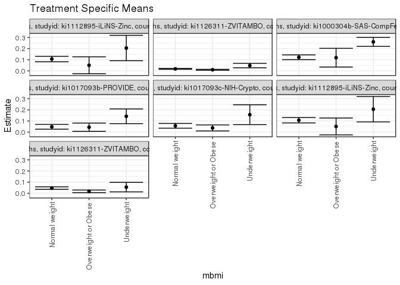

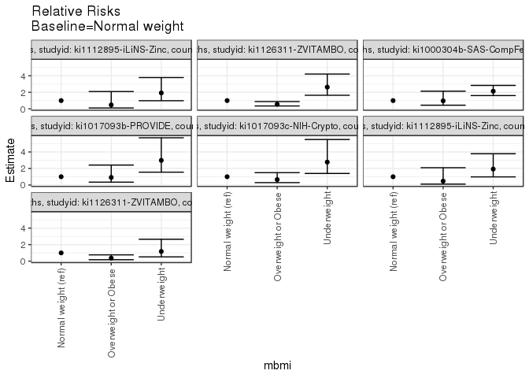

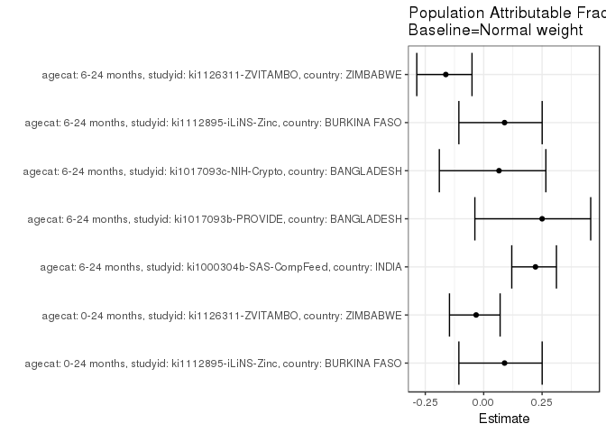

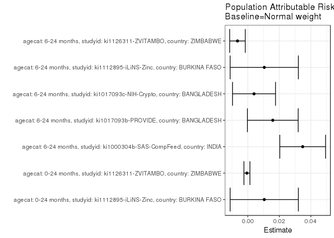

## Results Table

### Parameter: TSM

| agecat | studyid | country | intervention_level | baseline_level | estimate | ci_lower | ci_upper |
| --- | --- | --- | --- | --- | --- | --- | --- |
| 0-24 months | ki1112895-iLiNS-Zinc | BURKINA FASO | Normal weight | NA | 0.1065134 | 0.0820823 | 0.1309446 |
| 0-24 months | ki1112895-iLiNS-Zinc | BURKINA FASO | Underweight | NA | 0.2052402 | 0.0910824 | 0.3193980 |
| 0-24 months | ki1112895-iLiNS-Zinc | BURKINA FASO | Overweight or Obese | NA | 0.0505051 | -0.0254111 | 0.1264212 |
| 0-24 months | ki1126311-ZVITAMBO | ZIMBABWE | Normal weight | NA | 0.0180963 | 0.0145815 | 0.0216111 |
| 0-24 months | ki1126311-ZVITAMBO | ZIMBABWE | Underweight | NA | 0.0476190 | 0.0272512 | 0.0679869 |
| 0-24 months | ki1126311-ZVITAMBO | ZIMBABWE | Overweight or Obese | NA | 0.0100095 | 0.0057497 | 0.0142694 |
| 6-24 months | ki1000304b-SAS-CompFeed | INDIA | Normal weight | NA | 0.1222367 | 0.1008578 | 0.1436156 |
| 6-24 months | ki1000304b-SAS-CompFeed | INDIA | Underweight | NA | 0.2607143 | 0.2202664 | 0.3011622 |
| 6-24 months | ki1000304b-SAS-CompFeed | INDIA | Overweight or Obese | NA | 0.1186441 | 0.0343650 | 0.2029232 |
| 6-24 months | ki1017093b-PROVIDE | BANGLADESH | Normal weight | NA | 0.0474934 | 0.0260625 | 0.0689244 |
| 6-24 months | ki1017093b-PROVIDE | BANGLADESH | Underweight | NA | 0.1415094 | 0.0751018 | 0.2079170 |
| 6-24 months | ki1017093b-PROVIDE | BANGLADESH | Overweight or Obese | NA | 0.0434783 | 0.0061752 | 0.0807814 |
| 6-24 months | ki1017093c-NIH-Crypto | BANGLADESH | Normal weight | NA | 0.0563063 | 0.0348496 | 0.0777630 |
| 6-24 months | ki1017093c-NIH-Crypto | BANGLADESH | Underweight | NA | 0.1562500 | 0.0672302 | 0.2452698 |
| 6-24 months | ki1017093c-NIH-Crypto | BANGLADESH | Overweight or Obese | NA | 0.0370370 | 0.0100937 | 0.0639804 |
| 6-24 months | ki1112895-iLiNS-Zinc | BURKINA FASO | Normal weight | NA | 0.1065134 | 0.0820823 | 0.1309446 |
| 6-24 months | ki1112895-iLiNS-Zinc | BURKINA FASO | Underweight | NA | 0.2052402 | 0.0910824 | 0.3193980 |
| 6-24 months | ki1112895-iLiNS-Zinc | BURKINA FASO | Overweight or Obese | NA | 0.0505051 | -0.0254111 | 0.1264212 |
| 6-24 months | ki1126311-ZVITAMBO | ZIMBABWE | Normal weight | NA | 0.0467963 | 0.0356865 | 0.0579061 |
| 6-24 months | ki1126311-ZVITAMBO | ZIMBABWE | Underweight | NA | 0.0550459 | 0.0122193 | 0.0978724 |
| 6-24 months | ki1126311-ZVITAMBO | ZIMBABWE | Overweight or Obese | NA | 0.0172414 | 0.0053944 | 0.0290884 |

### Parameter: E(Y)

| agecat | studyid | country | intervention_level | baseline_level | estimate | ci_lower | ci_upper |
| --- | --- | --- | --- | --- | --- | --- | --- |
| 0-24 months | ki1112895-iLiNS-Zinc | BURKINA FASO | NA | NA | 0.1169626 | 0.0922087 | 0.1417166 |
| 0-24 months | ki1126311-ZVITAMBO | ZIMBABWE | NA | NA | 0.0175286 | 0.0146606 | 0.0203965 |
| 6-24 months | ki1000304b-SAS-CompFeed | INDIA | NA | NA | 0.1570397 | 0.1416255 | 0.1724539 |
| 6-24 months | ki1017093b-PROVIDE | BANGLADESH | NA | NA | 0.0633333 | 0.0438284 | 0.0828382 |
| 6-24 months | ki1017093c-NIH-Crypto | BANGLADESH | NA | NA | 0.0602582 | 0.0425793 | 0.0779372 |
| 6-24 months | ki1112895-iLiNS-Zinc | BURKINA FASO | NA | NA | 0.1169626 | 0.0922087 | 0.1417166 |
| 6-24 months | ki1126311-ZVITAMBO | ZIMBABWE | NA | NA | 0.0402650 | 0.0315644 | 0.0489656 |

### Parameter: RR

| agecat | studyid | country | intervention_level | baseline_level | estimate | ci_lower | ci_upper |
| --- | --- | --- | --- | --- | --- | --- | --- |
| 0-24 months | ki1112895-iLiNS-Zinc | BURKINA FASO | Normal weight | Normal weight | 1.0000000 | 1.0000000 | 1.0000000 |
| 0-24 months | ki1112895-iLiNS-Zinc | BURKINA FASO | Underweight | Normal weight | 1.9268952 | 0.9809928 | 3.7848648 |
| 0-24 months | ki1112895-iLiNS-Zinc | BURKINA FASO | Overweight or Obese | Normal weight | 0.4741661 | 0.1073138 | 2.0951041 |
| 0-24 months | ki1126311-ZVITAMBO | ZIMBABWE | Normal weight | Normal weight | 1.0000000 | 1.0000000 | 1.0000000 |
| 0-24 months | ki1126311-ZVITAMBO | ZIMBABWE | Underweight | Normal weight | 2.6314286 | 1.6450453 | 4.2092557 |
| 0-24 months | ki1126311-ZVITAMBO | ZIMBABWE | Overweight or Obese | Normal weight | 0.5531268 | 0.3464649 | 0.8830599 |
| 6-24 months | ki1000304b-SAS-CompFeed | INDIA | Normal weight | Normal weight | 1.0000000 | 1.0000000 | 1.0000000 |
| 6-24 months | ki1000304b-SAS-CompFeed | INDIA | Underweight | Normal weight | 2.1328647 | 1.6045321 | 2.8351642 |
| 6-24 months | ki1000304b-SAS-CompFeed | INDIA | Overweight or Obese | Normal weight | 0.9706094 | 0.4409000 | 2.1367266 |
| 6-24 months | ki1017093b-PROVIDE | BANGLADESH | Normal weight | Normal weight | 1.0000000 | 1.0000000 | 1.0000000 |
| 6-24 months | ki1017093b-PROVIDE | BANGLADESH | Underweight | Normal weight | 2.9795597 | 1.5538628 | 5.7133589 |
| 6-24 months | ki1017093b-PROVIDE | BANGLADESH | Overweight or Obese | Normal weight | 0.9154590 | 0.3472439 | 2.4134766 |
| 6-24 months | ki1017093c-NIH-Crypto | BANGLADESH | Normal weight | Normal weight | 1.0000000 | 1.0000000 | 1.0000000 |
| 6-24 months | ki1017093c-NIH-Crypto | BANGLADESH | Underweight | Normal weight | 2.7750000 | 1.3982600 | 5.5072913 |
| 6-24 months | ki1017093c-NIH-Crypto | BANGLADESH | Overweight or Obese | Normal weight | 0.6577778 | 0.2893483 | 1.4953315 |
| 6-24 months | ki1112895-iLiNS-Zinc | BURKINA FASO | Normal weight | Normal weight | 1.0000000 | 1.0000000 | 1.0000000 |
| 6-24 months | ki1112895-iLiNS-Zinc | BURKINA FASO | Underweight | Normal weight | 1.9268952 | 0.9809928 | 3.7848648 |
| 6-24 months | ki1112895-iLiNS-Zinc | BURKINA FASO | Overweight or Obese | Normal weight | 0.4741661 | 0.1073138 | 2.0951041 |
| 6-24 months | ki1126311-ZVITAMBO | ZIMBABWE | Normal weight | Normal weight | 1.0000000 | 1.0000000 | 1.0000000 |
| 6-24 months | ki1126311-ZVITAMBO | ZIMBABWE | Underweight | Normal weight | 1.1762879 | 0.5214884 | 2.6532771 |
| 6-24 months | ki1126311-ZVITAMBO | ZIMBABWE | Overweight or Obese | Normal weight | 0.3684350 | 0.1780884 | 0.7622304 |

### Parameter: PAR

| agecat | studyid | country | intervention_level | baseline_level | estimate | ci_lower | ci_upper |
| --- | --- | --- | --- | --- | --- | --- | --- |
| 0-24 months | ki1112895-iLiNS-Zinc | BURKINA FASO | Normal weight | NA | 0.0104492 | -0.0111788 | 0.0320772 |
| 0-24 months | ki1126311-ZVITAMBO | ZIMBABWE | Normal weight | NA | -0.0005677 | -0.0024665 | 0.0013312 |
| 6-24 months | ki1000304b-SAS-CompFeed | INDIA | Normal weight | NA | 0.0348030 | 0.0202814 | 0.0493247 |
| 6-24 months | ki1017093b-PROVIDE | BANGLADESH | Normal weight | NA | 0.0158399 | -0.0002689 | 0.0319488 |
| 6-24 months | ki1017093c-NIH-Crypto | BANGLADESH | Normal weight | NA | 0.0039519 | -0.0097003 | 0.0176042 |
| 6-24 months | ki1112895-iLiNS-Zinc | BURKINA FASO | Normal weight | NA | 0.0104492 | -0.0111788 | 0.0320772 |
| 6-24 months | ki1126311-ZVITAMBO | ZIMBABWE | Normal weight | NA | -0.0065312 | -0.0114675 | -0.0015950 |

### Parameter: PAF

| agecat | studyid | country | intervention_level | baseline_level | estimate | ci_lower | ci_upper |
| --- | --- | --- | --- | --- | --- | --- | --- |
| 0-24 months | ki1112895-iLiNS-Zinc | BURKINA FASO | Normal weight | NA | 0.0893382 | -0.1062503 | 0.2503461 |
| 0-24 months | ki1126311-ZVITAMBO | ZIMBABWE | Normal weight | NA | -0.0323859 | -0.1464628 | 0.0703399 |
| 6-24 months | ki1000304b-SAS-CompFeed | INDIA | Normal weight | NA | 0.2216194 | 0.1201265 | 0.3114051 |
| 6-24 months | ki1017093b-PROVIDE | BANGLADESH | Normal weight | NA | 0.2501042 | -0.0377805 | 0.4581284 |
| 6-24 months | ki1017093c-NIH-Crypto | BANGLADESH | Normal weight | NA | 0.0655834 | -0.1898888 | 0.2662051 |
| 6-24 months | ki1112895-iLiNS-Zinc | BURKINA FASO | Normal weight | NA | 0.0893382 | -0.1062503 | 0.2503461 |
| 6-24 months | ki1126311-ZVITAMBO | ZIMBABWE | Normal weight | NA | -0.1622058 | -0.2863881 | -0.0500114 |